# Macroinvertebrados

El set de datos se compone de un muestreo realizado como se ve en el siguiente grÃ¡fico:

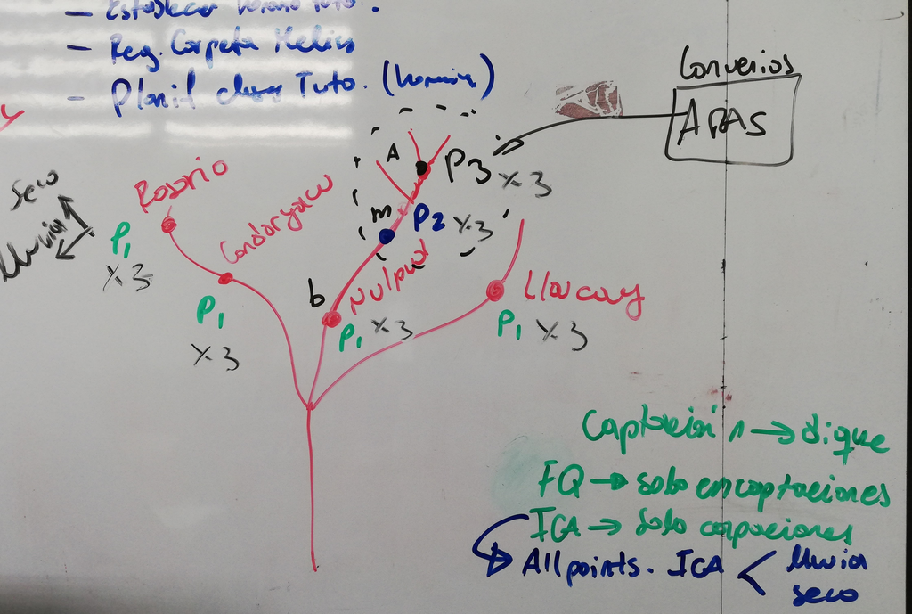

```r
library(readxl)
macroinv <- read_excel("macroinv.xlsx", sheet = "macro")
mi<-data.frame(quebrada=macroinv$quebrada,temp=macroinv$temp,lugar=macroinv$lugar,fecha=macroinv$fecha,orden=macroinv$orden,familia=macroinv$familia,conteo=macroinv$conteo,abi=macroinv$abi,bmw=macroinv$bmw,stringsAsFactors = T)
str(mi)
```

```
'data.frame':   889 obs. of  9 variables:
 $ quebrada: Factor w/ 4 levels "condoryacu","llaucay",..: 3 3 3 3 3 3 3 3 3 3 ...
 $ temp    : Factor w/ 2 levels "lluvia","seco": 2 2 2 2 2 2 2 2 2 2 ...
 $ lugar   : Factor w/ 3 levels "p1","p2","p3": 1 1 1 1 1 1 1 1 1 1 ...
 $ fecha   : Factor w/ 14 levels "06.03.18","07.03.18",..: 3 6 8 3 6 8 3 6 8 3 ...
 $ orden   : Factor w/ 31 levels "amphipoda","basommatophora",..: 1 1 1 4 4 4 4 4 4 4 ...
 $ familia : Factor w/ 75 levels "anomalopsychidae",..: 29 29 29 68 68 68 16 16 16 32 ...
 $ conteo  : num  210 114 261 8 4 9 4 1 4 1 ...
 $ abi     : num  6 6 6 5 5 5 5 5 5 5 ...
 $ bmw     : num  7 7 7 7 7 7 6 6 6 9 ...
```

```r
head(mi)
```

|  | quebrada | temp | lugar | fecha | orden | familia | conteo | abi | bmw |
| --- | --- | --- | --- | --- | --- | --- | --- | --- | --- |
| 1 | nudpud | seco | p1 | 08.03.18 | amphipoda | hyalellidae | 210 | 6 | 7 |
| 2 | nudpud | seco | p1 | 12.03.18 | amphipoda | hyalellidae | 114 | 6 | 7 |
| 3 | nudpud | seco | p1 | 19.03.18 | amphipoda | hyalellidae | 261 | 6 | 7 |
| 4 | nudpud | seco | p1 | 08.03.18 | coleoptera | scirtidae | 8 | 5 | 7 |
| 5 | nudpud | seco | p1 | 12.03.18 | coleoptera | scirtidae | 4 | 5 | 7 |
| 6 | nudpud | seco | p1 | 19.03.18 | coleoptera | scirtidae | 9 | 5 | 7 |

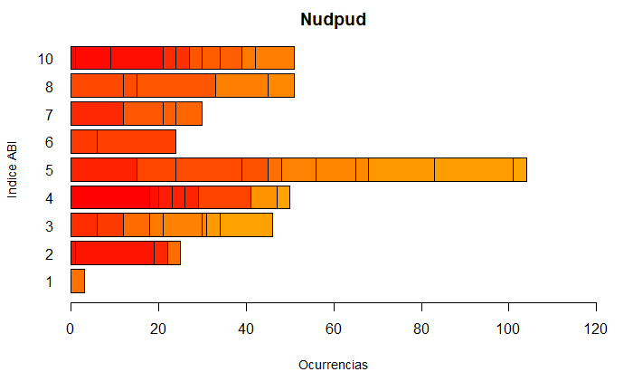

```r
#par(mfrow=c(2,2))
mi.nud<-data.frame(familia=mi$familia[mi$quebrada=="nudpud"],abi=mi$abi[mi$quebrada=="nudpud"])
t.nud.abi<-table(mi.nud$familia,mi.nud$abi)
barplot(t.nud.abi,horiz = T,main = "Nudpud",xlab = "Ocurrencias",ylab = "Indice ABI",cex.lab=0.9,xlim=c(0, 120),las=1,col=rainbow(length(t.nud.abi)))
```

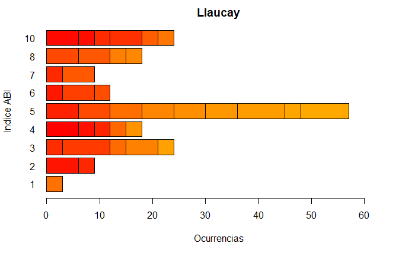

```r
mi.llau<-data.frame(familia=mi$familia[mi$quebrada=="llaucay"],abi=mi$abi[mi$quebrada=="llaucay"])
t.llau.abi<-table(mi.llau$familia,mi.llau$abi)
barplot(t.llau.abi,horiz = T,main = "Llaucay",xlab = "Ocurrencias",ylab = "Indice ABI",xlim=c(0, 65),las=1,col=rainbow(length(t.llau.abi)))
```

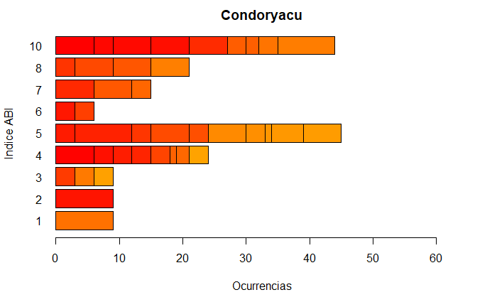

```r
mi.cond<-data.frame(familia=mi$familia[mi$quebrada=="condoryacu"],abi=mi$abi[mi$quebrada=="condoryacu"])
t.cond.abi<-table(mi.cond$familia,mi.cond$abi)
barplot(t.cond.abi,horiz = T,main = "Condoryacu",xlab = "Ocurrencias",ylab = "Indice ABI",xlim=c(0, 65),las=1,col=rainbow(length(t.cond.abi)))
```

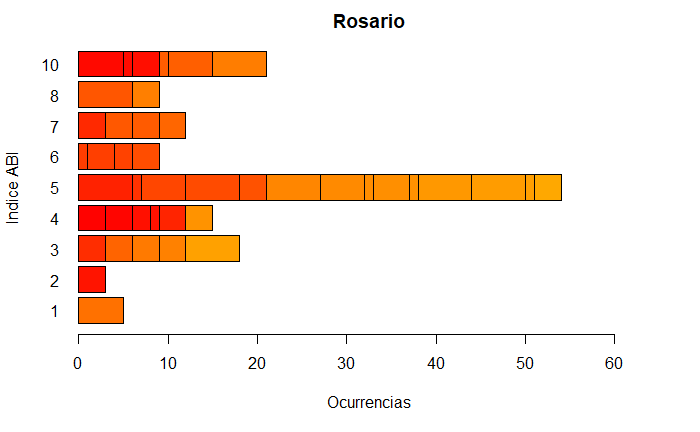

```r
mi.rosa<-data.frame(familia=mi$familia[mi$quebrada=="rosario"],abi=mi$abi[mi$quebrada=="rosario"])
t.rosa.abi<-table(mi.rosa$familia,mi.rosa$abi)
barplot(t.rosa.abi,horiz = T,main = "Rosario",xlab = "Ocurrencias",ylab = "Indice ABI",xlim=c(0, 65),las=1,col=rainbow(length(t.rosa.abi)))
```

```r
#t.nud.abi
#t.llau.abi
#t.cond.abi
#t.rosa.abi
```

```r
# Todos los datos
mi.cut.abi<-cut(mi$abi,breaks = c(1,3,6,10),include.lowest = T)
levels(mi.cut.abi)<-c("resistente","tolerante","sensible")
(mi<-data.frame(mi,tipo.macro=mi.cut.abi))
```

| quebrada | temp | lugar | fecha | orden | familia | conteo | abi | bmw | tipo.macro |
| --- | --- | --- | --- | --- | --- | --- | --- | --- | --- |
| nudpud | seco | p1 | 08.03.18 | amphipoda | hyalellidae | 210 | 6 | 7 | tolerante |
| nudpud | seco | p1 | 12.03.18 | amphipoda | hyalellidae | 114 | 6 | 7 | tolerante |
| nudpud | seco | p1 | 19.03.18 | amphipoda | hyalellidae | 261 | 6 | 7 | tolerante |
| nudpud | seco | p1 | 08.03.18 | coleoptera | scirtidae | 8 | 5 | 7 | tolerante |
| nudpud | seco | p1 | 12.03.18 | coleoptera | scirtidae | 4 | 5 | 7 | tolerante |
| nudpud | seco | p1 | 19.03.18 | coleoptera | scirtidae | 9 | 5 | 7 | tolerante |
| nudpud | seco | p1 | 08.03.18 | coleoptera | elmidae | 4 | 5 | 6 | tolerante |
| nudpud | seco | p1 | 12.03.18 | coleoptera | elmidae | 1 | 5 | 6 | tolerante |
| nudpud | seco | p1 | 19.03.18 | coleoptera | elmidae | 4 | 5 | 6 | tolerante |
| nudpud | seco | p1 | 08.03.18 | coleoptera | hydraenidae | 1 | 5 | 9 | tolerante |

[output cut: 879 more lines]

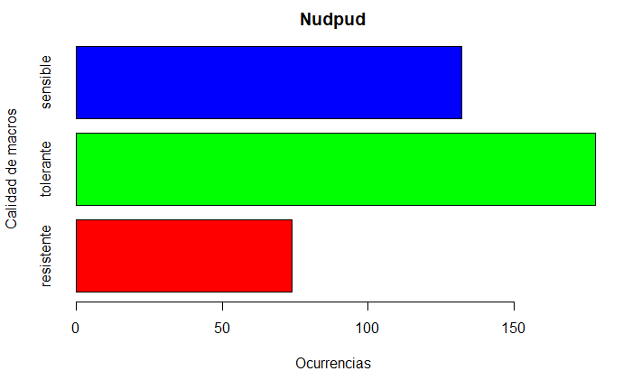

```r
t.mi.cut.abi.frec<-table(mi.cut.abi)
#cbind(t.mi.cut.abi.frec)
#par(mfrow=c(1,2))
mi.nud.cat<-data.frame(tipo.macro=mi$tipo.macro[mi$quebrada=="nudpud"],abi=mi$abi[mi$quebrada=="nudpud"])
tipo.macro.nud<-table(mi.nud.cat$tipo.macro)
barplot(tipo.macro.nud,horiz = T, main = "Nudpud", xlab = "Ocurrencias",ylab = "Calidad de macros",col = rainbow(length(tipo.macro.nud)))
```

```r
tipo.macro.nud
```

```
resistente  tolerante   sensible
        74        178        132
```

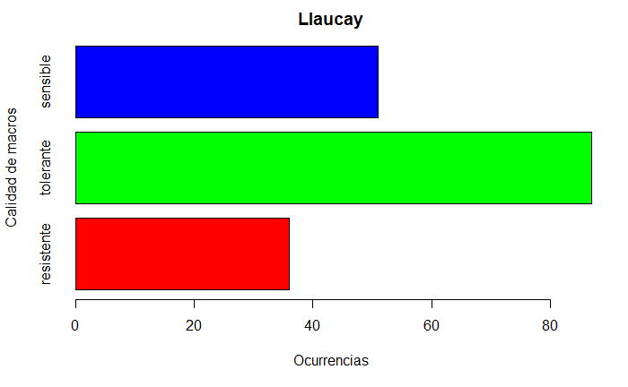

```r
mi.llau.cat<-data.frame(tipo.macro=mi$tipo.macro[mi$quebrada=="llaucay"],abi=mi$abi[mi$quebrada=="llaucay"])
tipo.macro.llau<-table(mi.llau.cat$tipo.macro)
barplot(tipo.macro.llau,horiz = T, main = "Llaucay", xlab = "Ocurrencias",ylab = "Calidad de macros",col = rainbow(length(tipo.macro.llau)))
```

```r
tipo.macro.llau
```

```
resistente  tolerante   sensible
        36         87         51
```

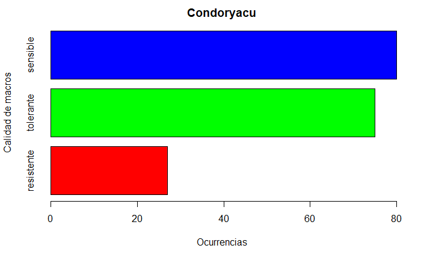

```r
#par(mfrow=c(1,2))
mi.cond.cat<-data.frame(tipo.macro=mi$tipo.macro[mi$quebrada=="condoryacu"],abi=mi$abi[mi$quebrada=="condoryacu"])
tipo.macro.cond<-table(mi.cond.cat$tipo.macro)
barplot(tipo.macro.cond,horiz = T, main = "Condoryacu", xlab = "Ocurrencias",ylab = "Calidad de macros",col = rainbow(length(tipo.macro.cond)))
```

```r
tipo.macro.cond
```

```
resistente  tolerante   sensible
        27         75         80
```

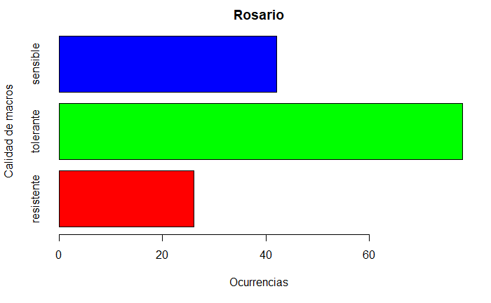

```r
mi.rosa.cat<-data.frame(tipo.macro=mi$tipo.macro[mi$quebrada=="rosario"],abi=mi$abi[mi$quebrada=="rosario"])
tipo.macro.rosa<-table(mi.rosa.cat$tipo.macro)
barplot(tipo.macro.rosa, horiz = T, main = "Rosario", xlab = "Ocurrencias",ylab = "Calidad de macros",col = rainbow(length(tipo.macro.rosa)))
```

```r
tipo.macro.rosa
```

```
resistente  tolerante   sensible
        26         78         42
```

```r
# Tabla y diangrama de barras de especies del rango de (1 a 3) RESISTENTES  de nudpud
library(ggplot2)
mi.nud<-data.frame(familia=mi$familia[mi$quebrada=="nudpud"],abi=mi$abi[mi$quebrada=="nudpud"])
abi.r<-data.frame(f=mi.nud$familia[mi.nud$abi>=1],abi=mi.nud$abi[mi.nud$abi>=1])
abi.r<-data.frame(f=mi.nud$familia[mi.nud$abi<=3],abi=mi.nud$abi[mi.nud$abi<=3])
head(abi.r)
```

|  | f | abi |
| --- | --- | --- |
| 1 | staphylinidae | 3 |
| 2 | staphylinidae | 3 |
| 3 | staphylinidae | 3 |
| 4 | chironomidae | 2 |
| 5 | chironomidae | 2 |
| 6 | chironomidae | 2 |

```r
(t5<-table(abi.r$abi))
```

```
 1  2  3
 3 25 46
```

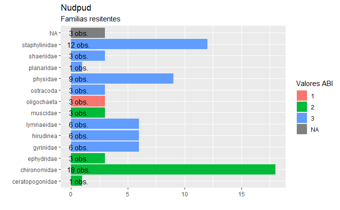

```r
ggplot(abi.r,aes(f,fill=factor(abi), position='dodge',))+geom_bar()+coord_flip()+geom_text(y=0.7, stat="count", aes(label=paste(..count.., "obs.")))+ggtitle("Nudpud",subtitle = "Familias resitentes")+xlab("") + ylab("")+theme(plot.title = element_text(hjust = 0))+theme(legend.position="right")+ guides(fill=guide_legend(title="Valores ABI"))
```

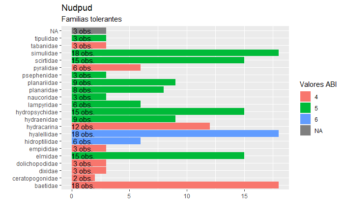

```r
# Diagrama de barras TOLERANTES
abi.t<-data.frame(f=mi.nud$familia[mi.nud$abi>=4],abi=mi.nud$abi[mi.nud$abi>=4])  # filtro >4
abi.t<-data.frame(f=abi.t$f[abi.t$abi<=6],abi=abi.t$abi[abi.t$abi<=6]) # filtro <6
ggplot(abi.t,aes(f,fill=factor(abi), position='dodge',))+geom_bar()+coord_flip()+geom_text(y=1, stat="count", aes(label=paste(..count.., "obs.")))+ggtitle("Nudpud",subtitle = "Familias tolerantes")+xlab("") + ylab("")+theme(plot.title = element_text(hjust = 0))+theme(legend.position="right")+ guides(fill=guide_legend(title="Valores ABI"))
```

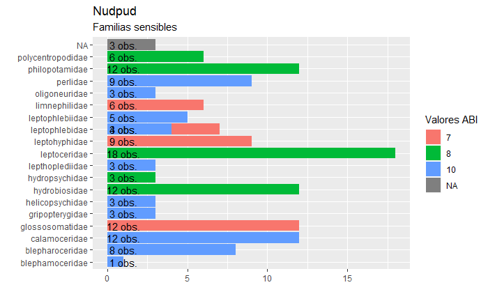

```r
# Diagrama de barras SENSIBLES
abi.t<-data.frame(f=mi.nud$familia[mi.nud$abi>=7],abi=mi.nud$abi[mi.nud$abi>=7])  # filtro >7
abi.t<-data.frame(f=abi.t$f[abi.t$abi<=10],abi=abi.t$abi[abi.t$abi<=10]) # filtro <10
ggplot(abi.t,aes(f,fill=factor(abi), position='dodge',))+geom_bar()+coord_flip()+geom_text(y=1, stat="count", aes(label=paste(..count.., "obs.")))+ggtitle("Nudpud",subtitle = "Familias sensibles")+xlab("") + ylab("")+theme(plot.title = element_text(hjust = 0))+theme(legend.position="right")+ guides(fill=guide_legend(title="Valores ABI"))
```

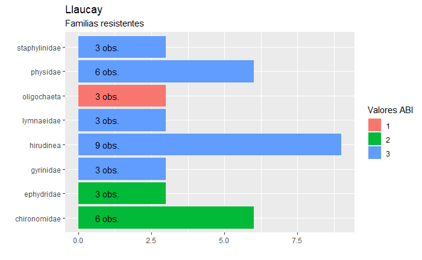

```r
# Llaucay
mi.llau<-data.frame(familia=mi$familia[mi$quebrada=="llaucay"],abi=mi$abi[mi$quebrada=="llaucay"])
# Diagrama de barras RESISTENTES
abi.t<-data.frame(f=mi.llau$familia[mi.llau$abi>=1],abi=mi.llau$abi[mi.llau$abi>=1])  # filtro >1
abi.t<-data.frame(f=abi.t$f[abi.t$abi<=3],abi=abi.t$abi[abi.t$abi<=3]) # filtro <3
ggplot(abi.t,aes(f,fill=factor(abi), position='dodge',))+geom_bar()+coord_flip()+geom_text(y=1, stat="count", aes(label=paste(..count.., "obs.")))+ggtitle("Llaucay",subtitle = "Familias resistentes")+xlab("") + ylab("")+theme(plot.title = element_text(hjust = 0))+theme(legend.position="right")+ guides(fill=guide_legend(title="Valores ABI"))
```

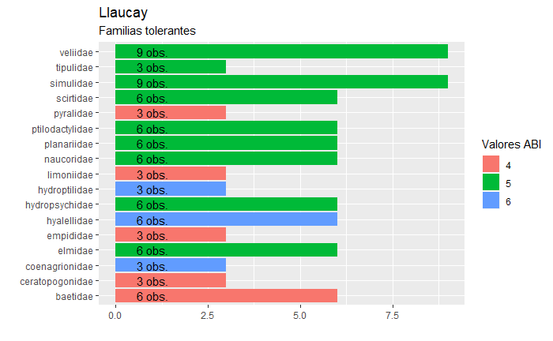

```r
# Diagrama de barras TOLERANTES
abi.t<-data.frame(f=mi.llau$familia[mi.llau$abi>=4],abi=mi.llau$abi[mi.llau$abi>=4])  # filtro >4
abi.t<-data.frame(f=abi.t$f[abi.t$abi<=6],abi=abi.t$abi[abi.t$abi<=6]) # filtro <6
ggplot(abi.t,aes(f,fill=factor(abi), position='dodge',))+geom_bar()+coord_flip()+geom_text(y=1, stat="count", aes(label=paste(..count.., "obs.")))+ggtitle("Llaucay",subtitle = "Familias tolerantes")+xlab("") + ylab("")+theme(plot.title = element_text(hjust = 0))+theme(legend.position="right")+ guides(fill=guide_legend(title="Valores ABI"))
```

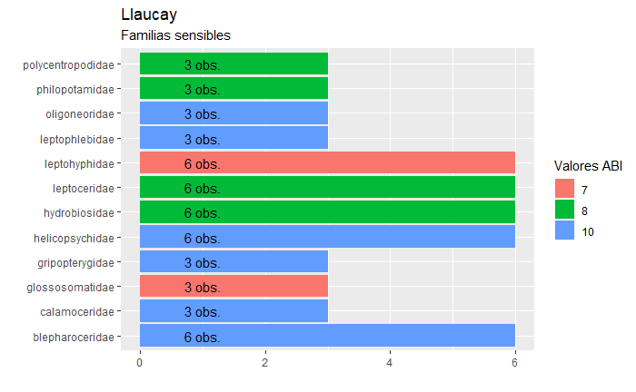

```r
# Diagrama de barras SENSIBLES
abi.t<-data.frame(f=mi.llau$familia[mi.llau$abi>=7],abi=mi.llau$abi[mi.llau$abi>=7])  # filtro >7
abi.t<-data.frame(f=abi.t$f[abi.t$abi<=10],abi=abi.t$abi[abi.t$abi<=10]) # filtro <10
ggplot(abi.t,aes(f,fill=factor(abi), position='dodge',))+geom_bar()+coord_flip()+geom_text(y=1, stat="count", aes(label=paste(..count.., "obs.")))+ggtitle("Llaucay",subtitle = "Familias sensibles")+xlab("") + ylab("")+theme(plot.title = element_text(hjust = 0))+theme(legend.position="right")+ guides(fill=guide_legend(title="Valores ABI"))
```

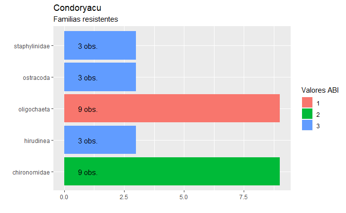

```r
# Consoryacu
mi.cond<-data.frame(familia=mi$familia[mi$quebrada=="condoryacu"],abi=mi$abi[mi$quebrada=="condoryacu"])
# Diagrama de barras RESISTENTES
abi.t<-data.frame(f=mi.cond$familia[mi.cond$abi>=1],abi=mi.cond$abi[mi.cond$abi>=1])  # filtro >1
abi.t<-data.frame(f=abi.t$f[abi.t$abi<=3],abi=abi.t$abi[abi.t$abi<=3]) # filtro <3
ggplot(abi.t,aes(f,fill=factor(abi), position='dodge',))+geom_bar()+coord_flip()+geom_text(y=1, stat="count", aes(label=paste(..count.., "obs.")))+ggtitle("Condoryacu",subtitle = "Familias resistentes")+xlab("") + ylab("")+theme(plot.title = element_text(hjust = 0))+theme(legend.position="right")+ guides(fill=guide_legend(title="Valores ABI"))
```

[figure not shown]

```r
# Diagrama de barras TOLERANTES
abi.t<-data.frame(f=mi.llau$familia[mi.llau$abi>=4],abi=mi.llau$abi[mi.llau$abi>=4])  # filtro >4
abi.t<-data.frame(f=abi.t$f[abi.t$abi<=6],abi=abi.t$abi[abi.t$abi<=6]) # filtro <6
ggplot(abi.t,aes(f,fill=factor(abi), position='dodge',))+geom_bar()+coord_flip()+geom_text(y=1, stat="count", aes(label=paste(..count.., "obs.")))+ggtitle("Condoryacu",subtitle = "Familias tolerantes")+xlab("") + ylab("")+theme(plot.title = element_text(hjust = 0))+theme(legend.position="right")+ guides(fill=guide_legend(title="Valores ABI"))
```

[figure not shown]

```r
# Diagrama de barras SENSIBLES
abi.t<-data.frame(f=mi.llau$familia[mi.llau$abi>=7],abi=mi.llau$abi[mi.llau$abi>=7])  # filtro >7
abi.t<-data.frame(f=abi.t$f[abi.t$abi<=10],abi=abi.t$abi[abi.t$abi<=10]) # filtro <10
ggplot(abi.t,aes(f,fill=factor(abi), position='dodge',))+geom_bar()+coord_flip()+geom_text(y=1, stat="count", aes(label=paste(..count.., "obs.")))+ggtitle("Condoryacu",subtitle = "Familias sensibles")+xlab("") + ylab("")+theme(plot.title = element_text(hjust = 0))+theme(legend.position="right")+ guides(fill=guide_legend(title="Valores ABI"))
```

[figure not shown]

[figure not shown]

[figure not shown]

## ANALISIS FÃSICO QUIMICOS

[output not shown]

```
    Bartlett test of homogeneity of variances

data:  ica by sitio
Bartlett's K-squared = 14.37, df = 3, p-value = 0.002442
```

[output not shown]

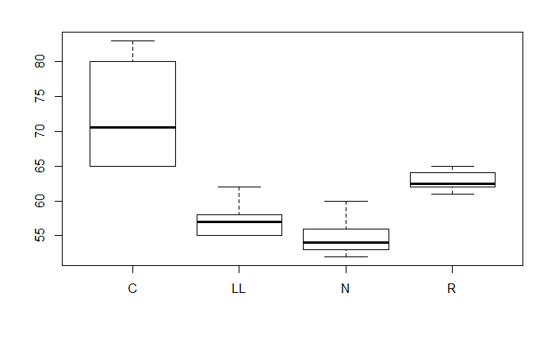

```
            Df Sum Sq Mean Sq F value   Pr(>F)
sitio        3 1083.0   361.0   17.43 8.42e-06 ***
Residuals   20  414.3    20.7
---
Signif. codes:  0 â***â 0.001 â**â 0.01 â*â 0.05 â.â 0.1 â â 1
```

[figure not shown]

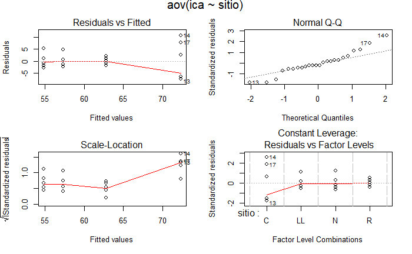

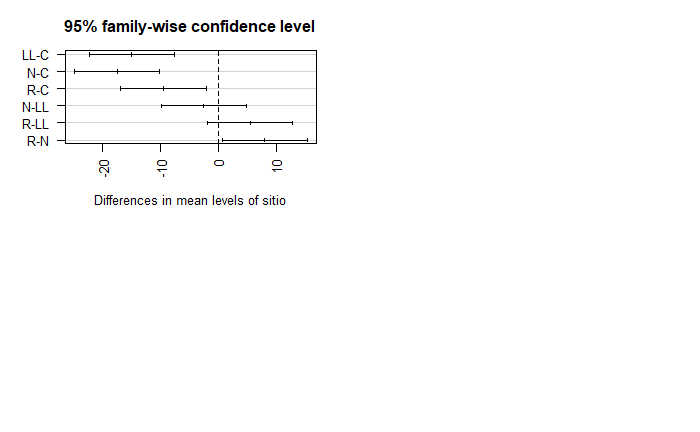

```
  Tukey multiple comparisons of means
    95% family-wise confidence level

Fit: aov(formula = ica ~ sitio, data = ica)

$sitio
      diff        lwr        upr     p adj
LL-C -15.0 -22.355163  -7.644837 0.0000760
N-C  -17.5 -24.855163 -10.144837 0.0000098
R-C   -9.5 -16.855163  -2.144837 0.0086143
N-LL  -2.5  -9.855163   4.855163 0.7778570
R-LL   5.5  -1.855163  12.855163 0.1894159
R-N    8.0   0.644837  15.355163 0.0299855
```

```
Call:
t1way(formula = ica ~ sitio, data = ica)

Test statistic: F = 20.8648
Degrees of freedom 1: 3
Degrees of freedom 2: 6.31
p-value: 0.00114

Explanatory measure of effect size: 1.18
```

```
Call:
lincon(formula = ica ~ sitio, data = ica)
NA
```

|  | psihat | ci.lower | ci.upper | p.value |
| --- | --- | --- | --- | --- |
| C vs. LL | 14.75 | -9.32468 | 38.82468 | 0.05026 |
| C vs. N | 17.25 | -6.95026 | 41.45026 | 0.03371 |
| C vs. R | 8.75 | -15.74902 | 33.24902 | 0.16222 |
| LL vs. N | 2.50 | -2.31974 | 7.31974 | 0.10589 |
| LL vs. R | -6.00 | -10.50146 | -1.49854 | 0.00324 |
| N vs. R | -8.50 | -12.62472 | -4.37528 | 0.00037 |